# Perspectives on Computational Modeling: Problem Set #8

#### Comparison

According to the plot below and the AUC values, the fitness of values are actially very close. The logistic regression gets the largest AUC value , while the random forest provides slightly lower AUC values. And the AUC values of random forest model and the decision tree model are very close.So the logistic regression model using random forest would be the best model. Wholly constructed by dummy variables, the performace of the three method in this context coule be close.

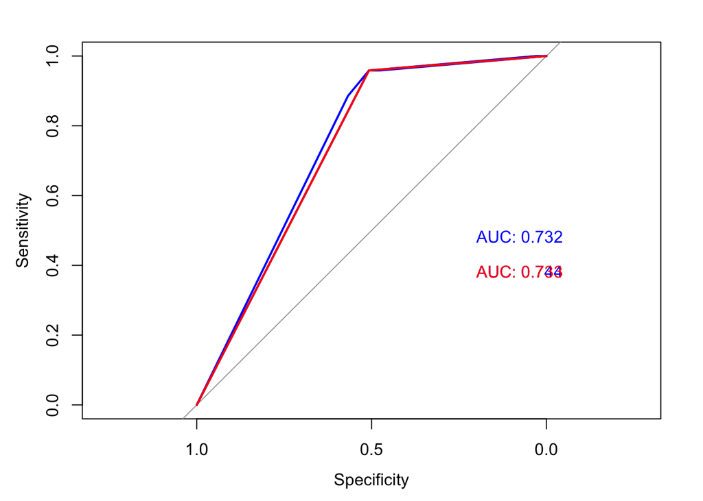

### 2. Predict whether individuals believe OJ Simpson to be guity

Since this question does not have specific predictors, I would use SVM models with all possible predictors for this part.

#### 2.1. linear kernel

```
##
## Call:
## best.tune(method = svm, train.x = guilt ~ dem + rep + age + educ +
##     female + black + hispanic + income, data = na.omit(as_tibble(simpson_split$train)),
##     ranges = list(cost = c(0.001, 0.01, 0.1, 1, 5, 10, 100)),
##     kernel = "linear")
##
##
## Parameters:
##    SVM-Type:  C-classification
##  SVM-Kernel:  linear
##        cost:  0.01
##       gamma:  0.0625
##
## Number of Support Vectors:  637
##
##  ( 329 308 )
##
##
## Number of Classes:  2
##
## Levels:
##  0 1
```

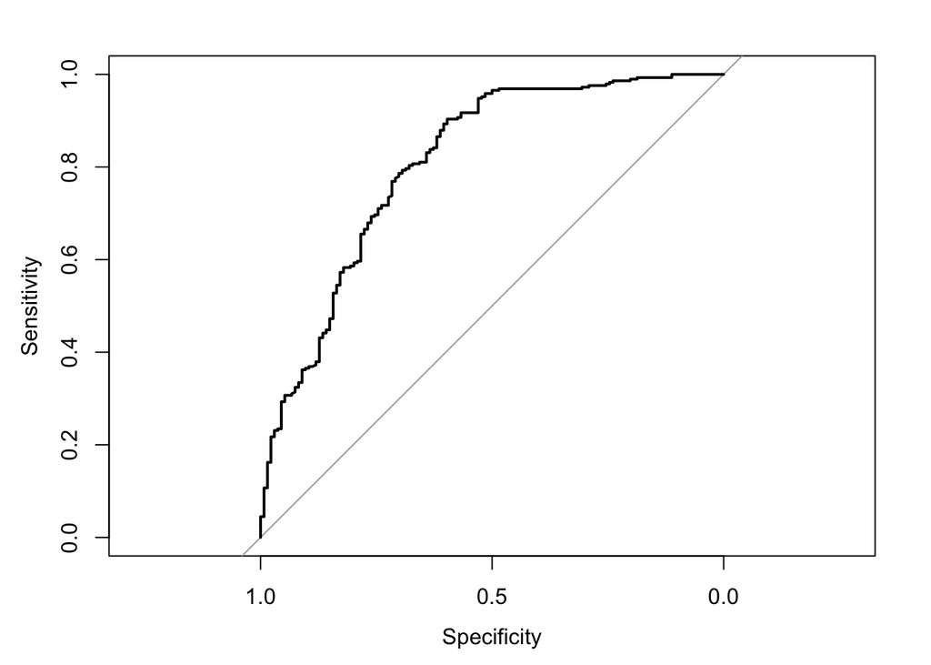

```
## Area under the curve: 0.808
```

#### 2.2 polynomial kernel

```
##
## Call:
## best.tune(method = svm, train.x = guilt ~ dem + rep + age + educ +
##     female + black + hispanic + income, data = na.omit(as_tibble(simpson_split$train)),
##     ranges = list(cost = c(0.001, 0.01, 0.1, 1, 5, 10, 100),
##         degree = c(3, 4, 5)), kernel = "polynomial")
##
##
## Parameters:
##    SVM-Type:  C-classification
##  SVM-Kernel:  polynomial
##        cost:  10
##      degree:  3
##       gamma:  0.0625
##      coef.0:  0
##
## Number of Support Vectors:  547
##
##  ( 302 245 )
##
##
## Number of Classes:  2
##
## Levels:
##  0 1
```

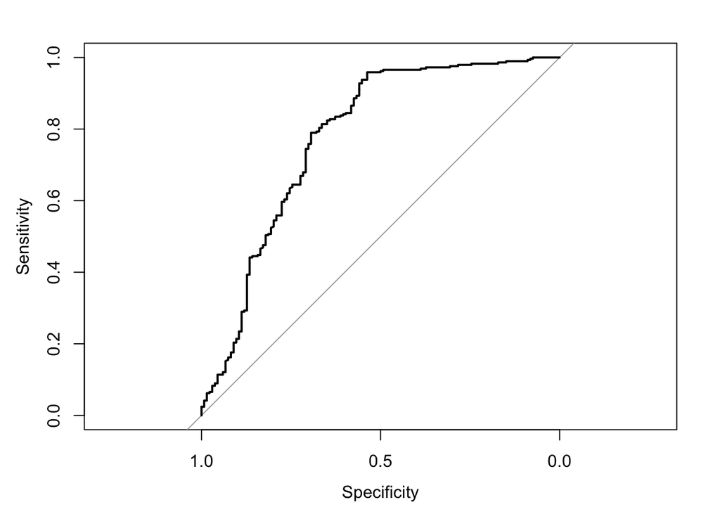

```
## Area under the curve: 0.778
```

#### 2.3: radial kernel

```
##
## Call:
## best.tune(method = svm, train.x = guilt ~ dem + rep + age + educ +
##     female + black + hispanic + income, data = na.omit(as_tibble(simpson_split$train)),
##     ranges = list(cost = c(0.001, 0.01, 0.1, 1, 5, 10, 100)),
##     kernel = "radial")
##
##
## Parameters:
##    SVM-Type:  C-classification
##  SVM-Kernel:  radial
##        cost:  1
##       gamma:  0.0625
##
## Number of Support Vectors:  489
##
##  ( 274 215 )
##
##
## Number of Classes:  2
##
## Levels:
##  0 1
```

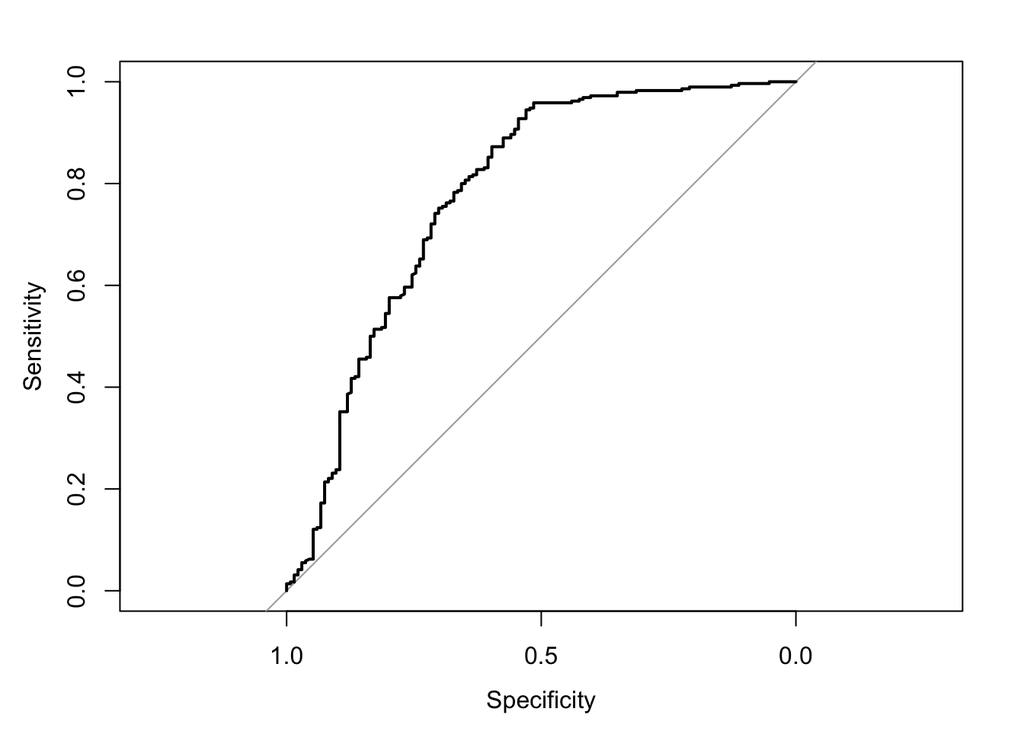

```
## Area under the curve: 0.781
```